# Mengarelli SI544 Final Report

Summer Mengarelli

12/10/2021

### The Data

My chosen dataset is taken from the eBird database. Ebird is an app/website run by the Cornell Lab of Ornithology, in which birdwatchers (from ornithologists to novices) can record bird observations. These observations are important contributions to wildlife biologists’ understanding of bird abundance, migration patterns, behaviors, etc. Ebird freely provides its data, and I was even able to request a custom dataset limited to a certain period of time (February 2019 to April 2020) and location (Charleston, South Carolina; this was arbitrary, but it’s my hometown). Within this dataset, each row is an individual observation made by a birder, and the variables contained in the columns are the birder’s responses to questions like bird common name and scientific name, observation count, date, locality, and number of observers. The columns also contain metadata like date the record was last edited and observer ID.

### The Goals

I would like to examine differences between two time periods: March-April 2019 and March-April 2020. My general suspicion is that because the United States was in lockdown during this time period in 2020, there will be distinct differences between the two years. My goals are to **report descriptive statistics** on several different variables, **wrangle the data** as necessary and **visualize results.** Then, I will **test two hypotheses** relating to data about the birders themselves, rather than the birds. My thought process is that while the Cornell Lab of Ornithology and other authorities use eBird data to draw conclusions about bird abundance, migration patterns, etc, in those cases this user-contributed data is supplemented with biological research and expertise. Because I have nothing but the raw data, I would rather study the birders submitting the data.

```r
library(ggplot2)
library(dplyr)
library(skimr)
library(RColorBrewer)
library(moderndive)
library(infer)
library(tidyverse)
```

Loading in the data:

```r
setwd("/Users/summermengarelli/Downloads/ebd_US-SC-019_201902_202004_relOct-2021")

ebird <- read.csv("ebird_csv.csv")
```

The very first thing I want to do is separate the OBSERVATION.DATE column into three columns for day, month, and year. I want to do this because I am interested specifically in comparing data from March-April 2019 and the same time period in 2020. I found this code on Stack Overflow and modified it for my use.

```r
ebird <- ebird %>%
  mutate(formatted_date = as.Date(OBSERVATION.DATE))

ebird <- ebird %>%
  mutate(year = as.numeric(format(formatted_date, format = "%Y")),
         month = as.numeric(format(formatted_date, format = "%m")),
         day = as.numeric(format(formatted_date, format = "%d")))
```

Now I can look at some summary statistics based on date. I’m going to look at my birthday, March 17, on both years. In 2020, this was the day that the governor of South Carolina ordered all restaurants to close dine-in, and public schools had already been closed for two days (Executive Order No. 2020-10). Then, I will do the same thing for April 17 in both years. In 2020, the governor had issued the state’s strictest lockdown, the “home or work” order, on April 6 (Executive Order No. 2020-21).

```r
birthday_birds <- ebird %>%
  filter(month == 3 & day == 17)

birthday_birds_totals <- birthday_birds %>%
 group_by(year) %>%
  summarize(total = n())

birthday_birds_totals
```

```
## # A tibble: 2 × 2
##    year total
##   <dbl> <int>
## 1  2019  1025
## 2  2020   576
```

```r
april_birds <- ebird %>%
  filter(month == 4 & day ==17)

april_birds_totals <- april_birds %>%
  group_by(year) %>%
  summarize(total = n())

april_birds_totals
```

```
## # A tibble: 2 × 2
##    year total
##   <dbl> <int>
## 1  2019  1455
## 2  2020   604
```

In both cases, there were around half as many observations on the date in 2020 as there were in 2019. This could mean that there were more birds in 2019, but of course the much likelier case is that there were more birdwatchers in 2019, while more people stayed at home in 2020. I would like to look at how many birders were out and about in March-April 2019 as opposed to March-April 2020 (this is represented by the OBSERVER.ID variable).

```r
ebird_19 <- ebird %>%
  filter(year == 2019 & month == 3 | year == 2019 & month == 4)

ebird_20 <- ebird %>%
  filter(year == 2020 & month == 3 | year == 2020 & month == 4)

birders_19 <- length(unique(ebird_19$OBSERVER.ID))
birders_19
```

```
## [1] 436
```

```r
birders_20 <- length(unique(ebird_20$OBSERVER.ID))
birders_20
```

```
## [1] 283
```

```r
birds_19 <- length(unique(ebird_19$COMMON.NAME))
birds_19
```

```
## [1] 288
```

```r
birds_20 <- length(unique(ebird_20$COMMON.NAME))
birds_20
```

```
## [1] 289
```

The numbers are very nearly identical, which tells me that the difference in observation counts is due to the disparity in number of birders, and I can’t really conclude anything about differences in bird populations between the two years. Next, I’m going to visualize the OBSERVATION.COUNT variable over the two-year span. This column indicates how many of the species recorded in the row were observed. Instead of NAs, the unanswered response is “X,” which simply indicates presence. Because of that, I felt it was appropriate to replace the Xs with 1s instead of excluding them; we know for sure that an “X” means at least one bird of that species was observed. Before visualizing, I ran a few descriptive statistics.

```r
ebird['OBSERVATION.COUNT'][ebird['OBSERVATION.COUNT'] == "X"] <- "1"

ebird <- ebird %>%
  mutate(observations = as.numeric(OBSERVATION.COUNT))

mean_observations = mean(ebird$observations)
mean_observations
```

```
## [1] 8.017215
```

```r
median_obser = median(ebird$observations)
median_obser
```

```
## [1] 2
```

```r
obs25 = quantile(ebird$observations, 0.25)
obs25
```

```
## 25%
##   1
```

```r
obs75 = quantile(ebird$observations, 0.75)
obs75
```

```
## 75%
##   5
```

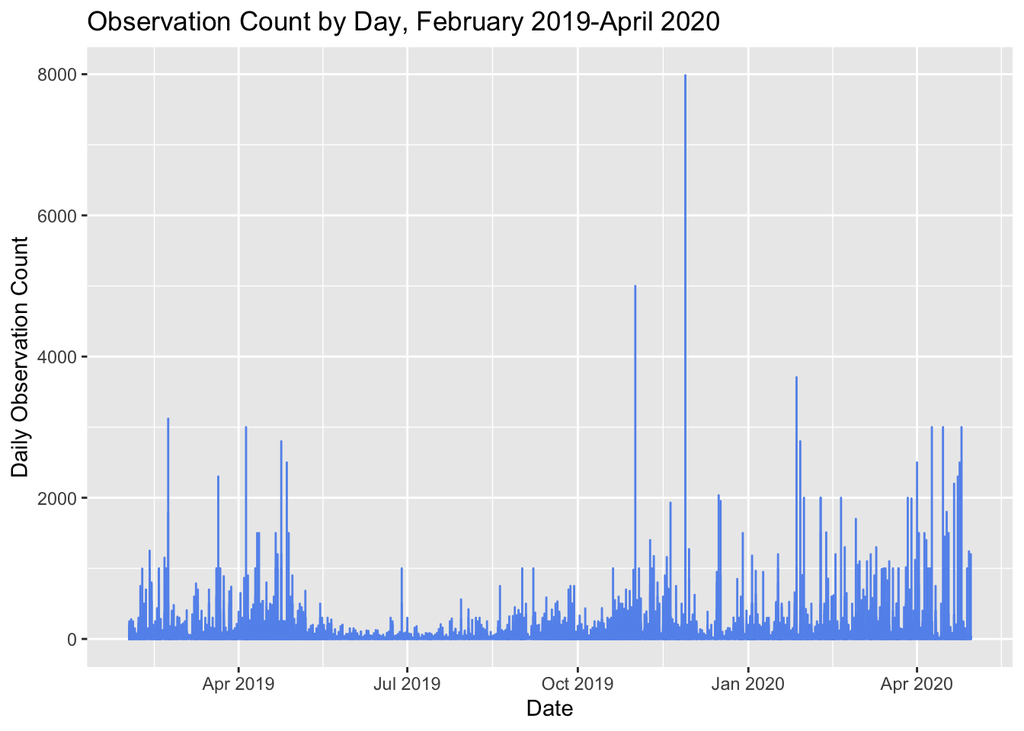

```r
ggplot(ebird, aes(x = formatted_date, y = observations)) +
  geom_line(color = "cornflowerblue") +
  xlab("Date") +
  ylab("Daily Observation Count") +
  labs(title = "Observation Count by Day, February 2019-April 2020")
```

```r
shorebird_survey <- ebird %>%
  filter(PROTOCOL.TYPE == "International Shorebird Survey (ISS)")

head(shorebird_survey %>%
  group_by(OBSERVATION.DATE) %>%
  tally())
```

```
## # A tibble: 6 × 2
##   OBSERVATION.DATE     n
##   <chr>            <int>
## 1 2019-02-08         200
## 2 2019-02-22          24
## 3 2019-03-09         212
## 4 2019-03-21           6
## 5 2019-03-23          34
## 6 2019-03-25           6
```

**Speaking of the ISS,** I next want to take a look at the types of birding activity. The data contains a column called PROTOCOL.TYPE that has a handful of values, like “Stationary”, “Traveling”, and “International Shorebird Survey (ISS)”. According to the metadata file eBird included when they sent me the dataset, these indicate the type of activity the birder was participating in at the time of the observation. As stated before, the ISS is a bird count event, as are a couple of the other possible values in this variable. There is also “Banding”, which accounts for a fairly small amount of the observations since only trained professionals can band birds. I’m particularly interested in the “Traveling” option, which includes observations made as the birder walked, biked, or otherwise traversed some distance; and the “Stationary” option, which includes backyard bird watching or sitting at a park. I wondered if the proportion of “Stationary” observations rose in 2020, so I completed the following visualizations and simple analyses:

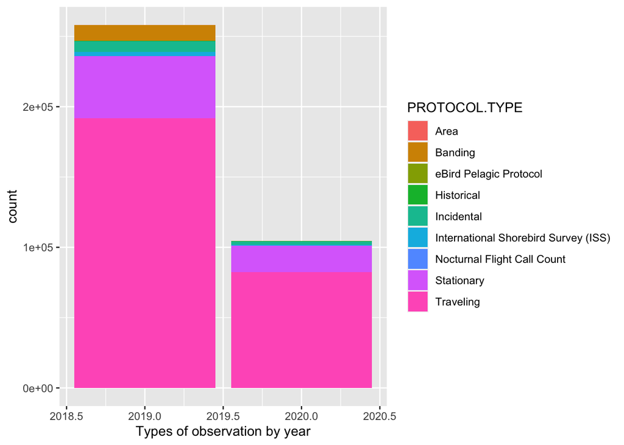

```r
ggplot(ebird, aes(x=year)) +
  geom_bar(aes(fill=PROTOCOL.TYPE))+
  labs(x = "Types of observation by year")
```

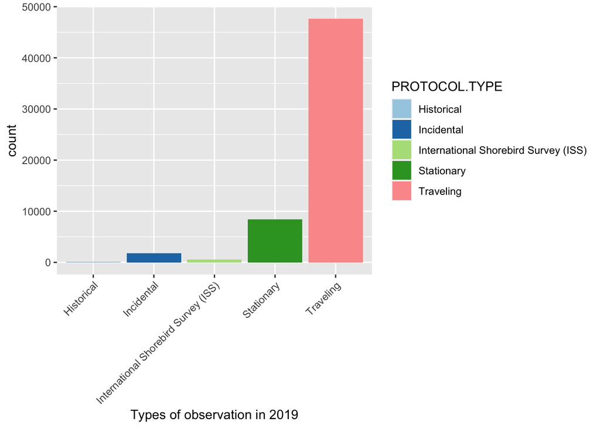

```r
ggplot(ebird_19, aes(x=PROTOCOL.TYPE, fill=PROTOCOL.TYPE)) +
  geom_bar()+
  labs(x = "Types of observation in 2019") +
  theme(axis.text.x = element_text(angle = 45, vjust = 1, hjust = 1))+
  scale_fill_brewer(palette = "Paired")
```

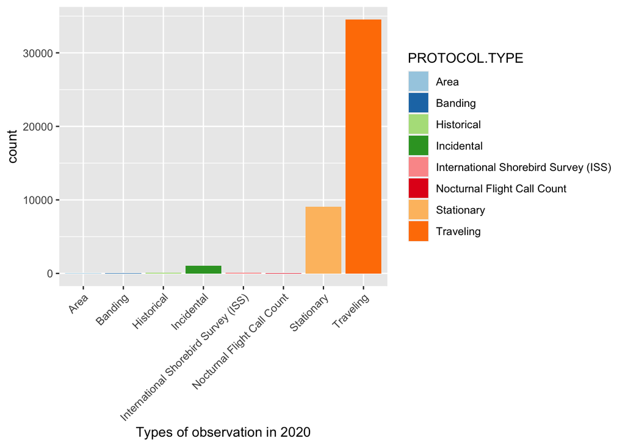

```r
ggplot(ebird_20, aes(x=PROTOCOL.TYPE, fill=PROTOCOL.TYPE)) +
  geom_bar()+
  labs(x = "Types of observation in 2020") +
  theme(axis.text.x = element_text(angle = 45, vjust = 1, hjust = 1))+
  scale_fill_brewer(palette = "Paired")
```

```r
prop_traveling19 <- sum(ebird_19$PROTOCOL.TYPE == "Traveling") / nrow(ebird_19)
prop_stationary19 <- sum(ebird_19$PROTOCOL.TYPE == "Stationary") / nrow(ebird_19)
prop_traveling19
```

```
## [1] 0.8143616
```

```r
prop_stationary19
```

```
## [1] 0.1431721
```

```r
prop_traveling20 <- sum(ebird_20$PROTOCOL.TYPE == "Traveling") / nrow(ebird_20)
prop_stationary20 <- sum(ebird_20$PROTOCOL.TYPE == "Stationary") / nrow(ebird_20)
prop_traveling20
```

```
## [1] 0.7693798
```

```r
prop_stationary20
```

```
## [1] 0.20184
```

Although the difference isn’t huge, and I didn’t complete any hypothesis testing for this variable, I can see that at least within this sample population, the proportion of “Traveling” observations decreased, and the proportion of “Stationary” observations increased, in the two-month period in 2020 as compared to 2019. This makes sense, as with lockdown restrictions it may have been the case that trail heads and other outdoor spaces were closed. On the other hand, I imagine that I’m not seeing a drastic change in proportions because realistically it is possible to walk or bike outside while maintaining social distancing.These explanations make sense to me, but I can’t actually conclude that the difference in proportions is because of pandemic restrictions, not simply an example of natural variation between years.

**For my actual hypotheses,** I want to look at birder group sizes. The numeric variable NUMBER.OBSERVERS indicates how many people were in the group that made the recorded observation. First, I want to get a sense of the numbers. This variable does contain NAs, and I decided the best idea was to remove them. Since I’m interested in whether or not birders were birding in groups, replacing NAs with 0 or 1 (to indicate *at least one person was in this group*) would artificially affect the analysis. I got the means of the number of observers during March-April in 2019 and in 2020, and then subtracted the two and saved the result in the variable **observed_diff_in_means** for later. Finally, I visualized the two groups in histograms.

```r
mean_observers_19 = mean(ebird_19$NUMBER.OBSERVERS, na.rm = T)
mean_observers_19
```

```
## [1] 4.486099
```

```r
mean_observers_20 = mean(ebird_20$NUMBER.OBSERVERS, na.rm = T)
mean_observers_20
```

```
## [1] 2.05064
```

```r
observed_diff_in_means <- mean_observers_19 - mean_observers_20
observed_diff_in_means
```

```
## [1] 2.435459
```

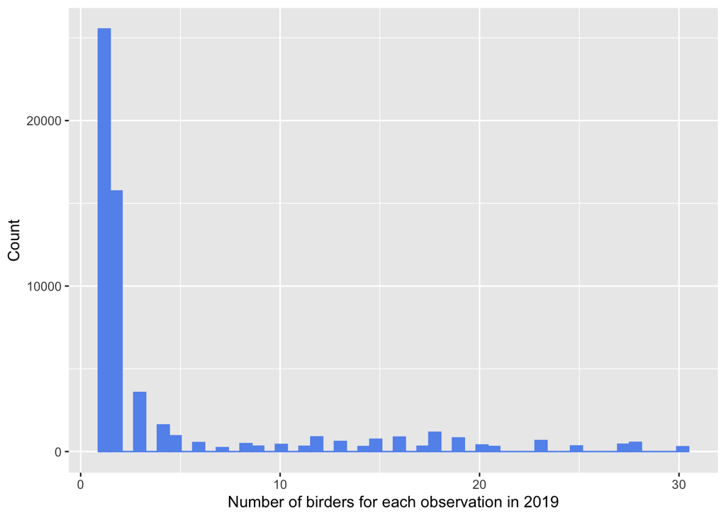

```r
ggplot(ebird_19, aes(x = NUMBER.OBSERVERS, na.rm = T))+
  geom_histogram(bins=50, color = "cornflowerblue", fill = "cornflowerblue")+
  ylab("Count")+
  xlab("Number of birders for each observation in 2019")
```

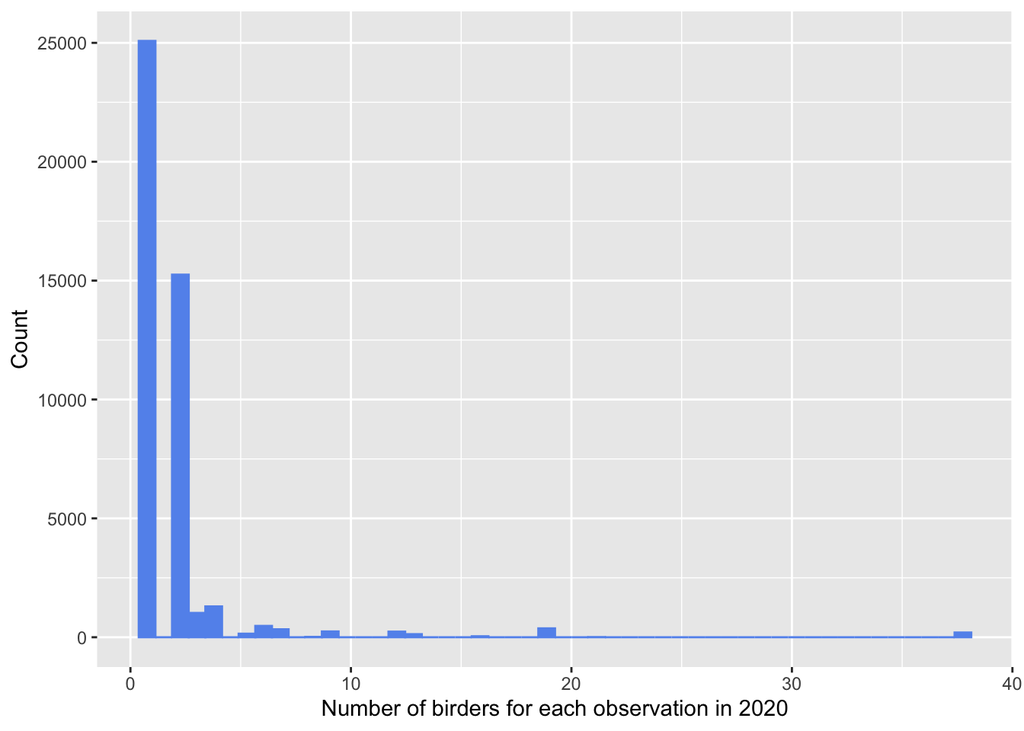

```r
ggplot(ebird_20, aes(x = NUMBER.OBSERVERS, na.rm = T))+
  geom_histogram(bins=50, color = "cornflowerblue", fill = "cornflowerblue")+
  ylab("Count")+
  xlab("Number of birders for each observation in 2020")
```

It’s difficult to conclude much from these graphs. Clearly, the number of observers in both years skews heavily toward fewer than 5. It appears that there were greater amounts of bigger groups in 2019 than in 2020, which would make sense given that large birding events were likely cancelled in 2020.

**My first hypothesis** is that birders birded in smaller groups in 2020 during the pandemic than they did in 2019 pre-pandemic. The following are the corresponding null and alternative hypotheses:

M<sub>b</sub> : Mean *before* the pandemic  
M<sub>p</sub> : Mean during the *pandemic*

H<sub>0</sub> : M<sub>b</sub> - M<sub>p</sub> <= 0  
H<sub>A</sub> : M<sub>b</sub> - M<sub>p</sub> > 0

In plain text, my alternative hypothesis is that the difference in means when I subtract 2020 from 2019 will be greater than 0, indicating that people birded in larger groups in 2019.

I first created a dataset containing only March & April of 2019 and 2020, and selected only a handful of columns. I ended up creating a new column, converting the year into characters, because without doing so I was getting error messages. Then, I followed the infer workflow as detailed in our textbook.

```r
march_april_2_years <- ebird %>% dplyr::select(GLOBAL.UNIQUE.IDENTIFIER, COMMON.NAME, NUMBER.OBSERVERS, TRIP.COMMENTS, year, month) %>%
  filter(year == 2019 & month == 3 | year == 2019 & month == 4 | year == 2020 & month == 3 | year == 2020 & month == 4)

march_april_2_years <- march_april_2_years %>%
  mutate(use_this_year = as.character(year))


head(march_april_2_years %>%
  group_by(use_this_year) %>%
  summarize(n = n(), mean_obs = mean(NUMBER.OBSERVERS, na.rm = T), std_dev = sd(NUMBER.OBSERVERS, na.rm = T)))
```

```
## # A tibble: 2 × 4
##   use_this_year     n mean_obs std_dev
##   <chr>         <int>    <dbl>   <dbl>
## 1 2019          58517     4.49    6.51
## 2 2020          44892     2.05    3.25
```

```r
null_distribution_means <- march_april_2_years %>%
  specify(formula = NUMBER.OBSERVERS ~ use_this_year) %>%
  hypothesize(null = "independence") %>%
  generate(reps = 1000, type = "permute") %>%
  calculate(stat = "diff in means", order = c("2019", "2020"))

head(null_distribution_means)
```

```
## Response: NUMBER.OBSERVERS (numeric)
## Explanatory: use_this_year (factor)
## Null Hypothesis: independence
## # A tibble: 6 × 2
##   replicate     stat
##       <int>    <dbl>
## 1         1 -0.0305
## 2         2 -0.00931
## 3         3 -0.0102
## 4         4  0.00425
## 5         5  0.0198
## 6         6 -0.0199
```

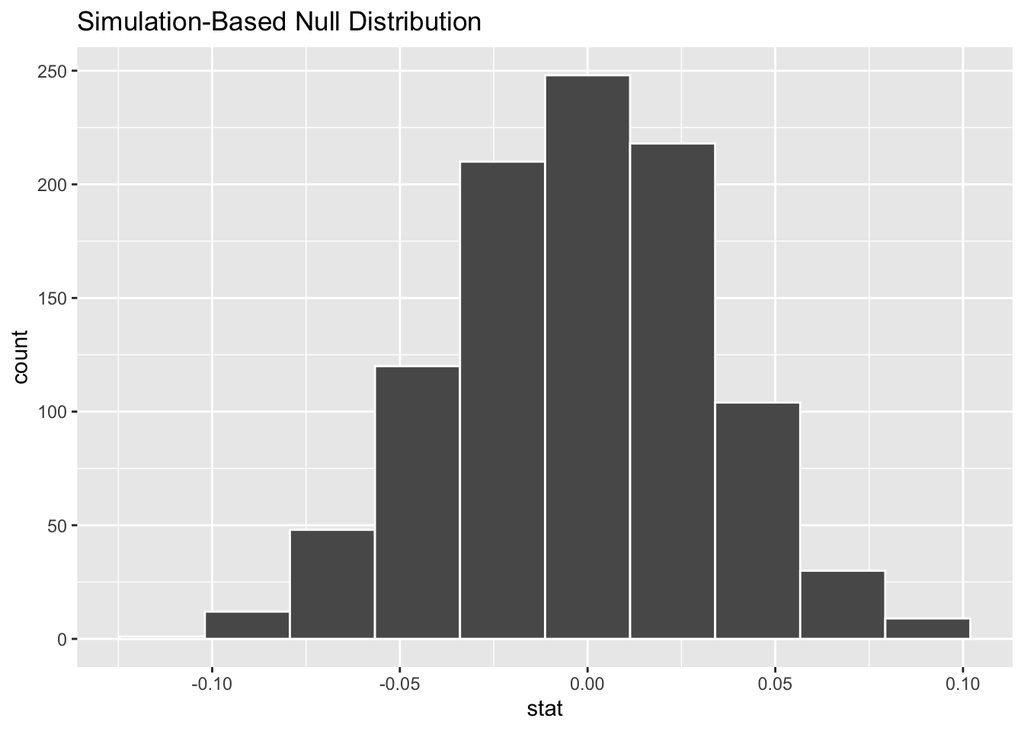

```r
visualize(null_distribution_means, bins = 10)
```

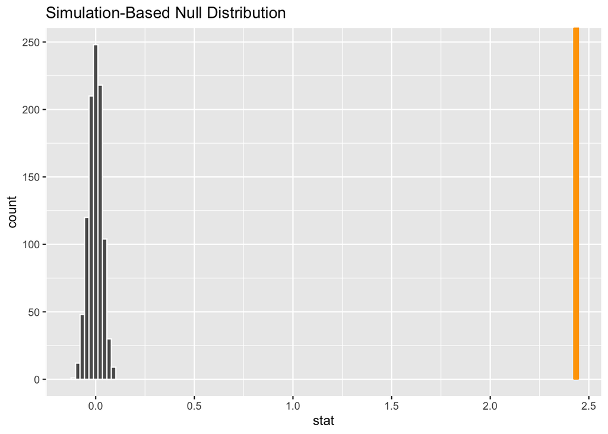

```r
visualize(null_distribution_means, bins = 10)+
  shade_p_value(obs_stat = observed_diff_in_means, direction = "right", color = "orange")
```

```r
null_distribution_means %>%
  get_p_value(obs_stat = observed_diff_in_means, direction = "right")
```

```
## # A tibble: 1 × 1
##   p_value
##     <dbl>
## 1       0
```

As the second visualization shows, the null distribution is nowhere near overlapping with the observed statistic. The p-value is very close to zero, which tells me that I can reject the null hypothesis and assume that the year (i.e., whether or not it was during lockdown/pandemic) had an affect on the average size of birding groups.

**I also wanted to know** more specifically whether more people birded alone during the pandemic. To prepare for this test, I created a copy of the dataset containing March-April of the two years, removed NAs in the NUMBER.OBSERVERS column, and created a new column in which a group size of 1 was designated by “Single” and all other group sizes fell into the category “Group.” I decided to construct a confidence interval for this test.

If I were to write null and alternative hypotheses for this test, they would go like:

P<sub>b</sub> : proportion of birders birding alone before the pandemic  
P<sub>p</sub> : proportion of birders birding alone during the pandemic

H<sub>0</sub> : P<sub>b</sub> - P<sub>p</sub> >= 0  
H<sub>A</sub> : P<sub>b</sub> - P<sub>p</sub> < 0

In words: The difference in proportions should be a negative number, indicating that the proportion of birders birding alone was greater in 2020 than in 2019. *Year* is the treatment variable, while *alone_or_not* is the response variable (8.6.1 of the textbook).

```r
copy_2_years <- march_april_2_years

copy_2_years <- copy_2_years %>% filter(!is.na(NUMBER.OBSERVERS))

copy_2_years <- copy_2_years %>%
  mutate(NUMBER.OBSERVERS = if_else(NUMBER.OBSERVERS == 1, "Single", "Group")) %>%
  mutate(alone_or_not = NUMBER.OBSERVERS)

bootstrap_distribution_alone <- copy_2_years %>%
  specify(formula = alone_or_not ~ use_this_year, success = "Single") %>%
  generate(reps = 1000, type = "bootstrap") %>%
  calculate(stat = "diff in props", order = c("2019", "2020"))

head(bootstrap_distribution_alone)
```

```
## Response: alone_or_not (factor)
## Explanatory: use_this_year (factor)
## # A tibble: 6 × 2
##   replicate   stat
##       <int>  <dbl>
## 1         1 -0.121
## 2         2 -0.127
## 3         3 -0.123
## 4         4 -0.125
## 5         5 -0.128
## 6         6 -0.127
```

```r
alone_ci_percent <- bootstrap_distribution_alone %>%
  get_confidence_interval(type = "percentile", level = 0.95)

alone_ci_percent
```

```
## # A tibble: 1 × 2
##   lower_ci upper_ci
##      <dbl>    <dbl>
## 1   -0.128   -0.116
```

```r
obs_diff_in_props <- copy_2_years %>%
  specify(formula = alone_or_not ~ use_this_year, success = "Single") %>%
  calculate(stat = "diff in props", order = c("2019", "2020"))

obs_diff_in_props
```

```
## Response: alone_or_not (factor)
## Explanatory: use_this_year (factor)
## # A tibble: 1 × 1
##     stat
##    <dbl>
## 1 -0.122
```

```r
alone_ci_se <- bootstrap_distribution_alone %>%
  get_confidence_interval(type = "se", point_estimate = obs_diff_in_props)

alone_ci_se
```

```
## # A tibble: 1 × 2
##   lower_ci upper_ci
##      <dbl>    <dbl>
## 1   -0.128   -0.116
```

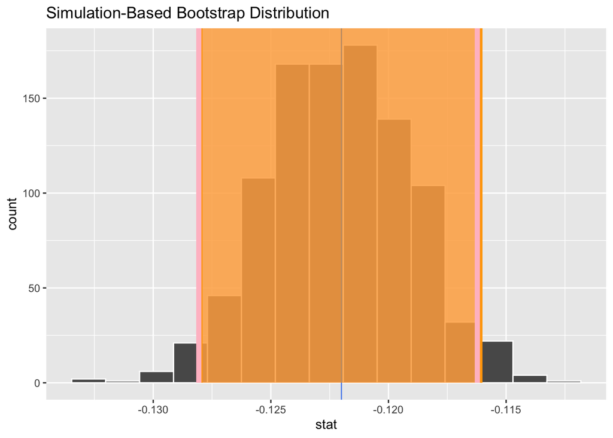

```r
visualize(bootstrap_distribution_alone) +
  shade_confidence_interval(endpoints = alone_ci_percent, color = "orange", fill = "pink") +
   geom_vline(xintercept = -.122, color = "cornflowerblue") +
  shade_confidence_interval(endpoints = alone_ci_se, color = "pink", fill = "orange")
```

The textbook interprets confidence intervals as follows: “If we repeated our sampling procedure a large number of times, we expect about 95% of the resulting confidence intervals to capture the value of the population parameter” (8.5.2). In other words, every time I bootstrap my sample population and construct CIs, there is a 95% chance that the CI will contain the actual difference in proportions. In this case, as seen in the visualization, the observed difference in proportions in contained within both the percentage and the standard error CIs. Also, since the CIs do not contain 0, I have evidence suggesting that the proportion of people birding alone was indeed affected by the pandemic.

**Nonetheless,** the difference is very small. This makes sense to me, as I’m sure many people still went birding with partners or housemates even during lockdown. A quick perusal of the free-text TRIP.COMMENTS column in 2020 suggested as much:

> “With Donna looking for butterflies”  
> “With Judy [last name removed], mostly cloudy, breezy, 66 F. Low tide was 6:45am”  
> “with Jane. Our first time exploring this beautiful area, looking forward to a return trip soon”

```r
finding_comment <- ebird %>%
  filter(str_detect(TRIP.COMMENTS, "My friend Joe came along"))
```

(^ Here I am looking for a comment that I saw just by scrolling through the copy_2_years dataset. I wanted to know the exact date, which was not a column I had retained from the original dataset.)

On March 22, 2020, a birder wrote this note in his observation:

> “Leading the weekly bird walk at Magnolia. My friend Joe came along. Cool, cloudy and overcast,, (basically a gray day and very slow), with a slight occasional breeze. The property was devoid of visitors. This may be the last bird walk for a while as I have been informed. I’m not sure. To our ‘regulars’, I’ll keep you posted.”

On March 21, 2020, the governor of South Carolina ordered law enforcement to break up crowds on state beaches; on March 23, the governor ordered any gathering of three or more people to be dispersed (Greenville News, March 23, 2020). I didn’t expect to be moved by a dataset, but working with this data reminded me just how much our lives have changed since 2020 — and getting to know the birders through their comments reminded me how data can only hint at the lives of the people it contains.